# Warming Stripes

2021/09/05 - 2022/03/13

## Install Packages

### Load Libraries

## Load Libraries

```r
library("tidyverse")       # for dates ymd( )
library("lubridate")       # for ggplot2; stringr str_c( )
library("RColorBrewer")    # for colour scheme
```

## Working Directory

is automatically set within project, so no need to reset

```r
getwd()
```

```
## [1] "/Users/wanthony/Documents/R/Presentations"
```

## Load Data

```r
climate_victoria <- read_csv("VictoriaINTL-INT'L-climate-daily-1940-2021.csv")
```

## get data info

```r
class(climate_victoria)
```

```
## [1] "spec_tbl_df" "tbl_df"      "tbl"         "data.frame"
```

```r
head(climate_victoria)
```

```
## # A tibble: 6 x 36
##       x     y STATION_NAME    CLIMATE_IDENTIFI… ID           LOCAL_DATE
##   <dbl> <dbl> <chr>                       <dbl> <chr>        <dttm>
## 1 -123.  48.6 VICTORIA INT'L…           1018620 1018620.194… 1940-07-01 00:00:00
## 2 -123.  48.6 VICTORIA INT'L…           1018620 1018620.194… 1940-07-02 00:00:00
## 3 -123.  48.6 VICTORIA INT'L…           1018620 1018620.194… 1940-07-03 00:00:00
## 4 -123.  48.6 VICTORIA INT'L…           1018620 1018620.194… 1940-07-04 00:00:00
## 5 -123.  48.6 VICTORIA INT'L…           1018620 1018620.194… 1940-07-05 00:00:00
## 6 -123.  48.6 VICTORIA INT'L…           1018620 1018620.194… 1940-07-06 00:00:00
## # … with 30 more variables: PROVINCE_CODE <chr>, LOCAL_YEAR <dbl>,
## #   LOCAL_MONTH <dbl>, LOCAL_DAY <dbl>, MEAN_TEMPERATURE <dbl>,
## #   MEAN_TEMPERATURE_FLAG <chr>, MIN_TEMPERATURE <dbl>,
## #   MIN_TEMPERATURE_FLAG <chr>, MAX_TEMPERATURE <dbl>,
## #   MAX_TEMPERATURE_FLAG <chr>, TOTAL_PRECIPITATION <dbl>,
## #   TOTAL_PRECIPITATION_FLAG <chr>, TOTAL_RAIN <dbl>, TOTAL_RAIN_FLAG <chr>,
## #   TOTAL_SNOW <dbl>, TOTAL_SNOW_FLAG <lgl>, SNOW_ON_GROUND <lgl>,
## #   SNOW_ON_GROUND_FLAG <lgl>, DIRECTION_MAX_GUST <lgl>,
## #   DIRECTION_MAX_GUST_FLAG <lgl>, SPEED_MAX_GUST <lgl>,
## #   SPEED_MAX_GUST_FLAG <lgl>, COOLING_DEGREE_DAYS <dbl>,
## #   COOLING_DEGREE_DAYS_FLAG <chr>, HEATING_DEGREE_DAYS <dbl>,
## #   HEATING_DEGREE_DAYS_FLAG <chr>, MIN_REL_HUMIDITY <lgl>,
## #   MIN_REL_HUMIDITY_FLAG <lgl>, MAX_REL_HUMIDITY <lgl>,
## #   MAX_REL_HUMIDITY_FLAG <lgl>
```

## more data info

**Click to see results of `str(climate_victoria)`**

```r
str(climate_victoria)
```

```
## spec_tbl_df [29,738 × 36] (S3: spec_tbl_df/tbl_df/tbl/data.frame)
##  $ x                       : num [1:29738] -123 -123 -123 -123 -123 ...
##  $ y                       : num [1:29738] 48.6 48.6 48.6 48.6 48.6 ...
##  $ STATION_NAME            : chr [1:29738] "VICTORIA INT'L A" "VICTORIA INT'L A" "VICTORIA INT'L A" "VICTORIA INT'L A" ...
##  $ CLIMATE_IDENTIFIER      : num [1:29738] 1018620 1018620 1018620 1018620 1018620 ...
##  $ ID                      : chr [1:29738] "1018620.1940.7.1" "1018620.1940.7.2" "1018620.1940.7.3" "1018620.1940.7.4" ...
##  $ LOCAL_DATE              : POSIXct[1:29738], format: "1940-07-01" "1940-07-02" ...
##  $ PROVINCE_CODE           : chr [1:29738] "BC" "BC" "BC" "BC" ...
##  $ LOCAL_YEAR              : num [1:29738] 1940 1940 1940 1940 1940 1940 1940 1940 1940 1940 ...
##  $ LOCAL_MONTH             : num [1:29738] 7 7 7 7 7 7 7 7 7 7 ...
##  $ LOCAL_DAY               : num [1:29738] 1 2 3 4 5 6 7 8 9 10 ...
##  $ MEAN_TEMPERATURE        : num [1:29738] NA NA NA NA NA NA NA NA NA NA ...
##  $ MEAN_TEMPERATURE_FLAG   : chr [1:29738] NA NA NA NA ...
##  $ MIN_TEMPERATURE         : num [1:29738] NA NA NA NA NA NA NA NA NA NA ...
##  $ MIN_TEMPERATURE_FLAG    : chr [1:29738] NA NA NA NA ...
##  $ MAX_TEMPERATURE         : num [1:29738] NA NA NA NA NA NA NA NA NA NA ...
##  $ MAX_TEMPERATURE_FLAG    : chr [1:29738] NA NA NA NA ...
##  $ TOTAL_PRECIPITATION     : num [1:29738] NA NA NA NA NA NA NA NA NA NA ...
##  $ TOTAL_PRECIPITATION_FLAG: chr [1:29738] "M" "M" "M" "M" ...
##  $ TOTAL_RAIN              : num [1:29738] NA NA NA NA NA NA NA NA NA NA ...
##  $ TOTAL_RAIN_FLAG         : chr [1:29738] "M" "M" "M" "M" ...
##  $ TOTAL_SNOW              : num [1:29738] 0 0 0 0 0 0 0 0 0 0 ...
##  $ TOTAL_SNOW_FLAG         : logi [1:29738] NA NA NA NA NA NA ...
##  $ SNOW_ON_GROUND          : logi [1:29738] NA NA NA NA NA NA ...
##  $ SNOW_ON_GROUND_FLAG     : logi [1:29738] NA NA NA NA NA NA ...
##  $ DIRECTION_MAX_GUST      : logi [1:29738] NA NA NA NA NA NA ...
##  $ DIRECTION_MAX_GUST_FLAG : logi [1:29738] NA NA NA NA NA NA ...
##  $ SPEED_MAX_GUST          : logi [1:29738] NA NA NA NA NA NA ...
##  $ SPEED_MAX_GUST_FLAG     : logi [1:29738] NA NA NA NA NA NA ...
##  $ COOLING_DEGREE_DAYS     : num [1:29738] NA NA NA NA NA NA NA NA NA NA ...
##  $ COOLING_DEGREE_DAYS_FLAG: chr [1:29738] NA NA NA NA ...
##  $ HEATING_DEGREE_DAYS     : num [1:29738] NA NA NA NA NA NA NA NA NA NA ...
##  $ HEATING_DEGREE_DAYS_FLAG: chr [1:29738] NA NA NA NA ...
##  $ MIN_REL_HUMIDITY        : logi [1:29738] NA NA NA NA NA NA ...
##  $ MIN_REL_HUMIDITY_FLAG   : logi [1:29738] NA NA NA NA NA NA ...
##  $ MAX_REL_HUMIDITY        : logi [1:29738] NA NA NA NA NA NA ...
##  $ MAX_REL_HUMIDITY_FLAG   : logi [1:29738] NA NA NA NA NA NA ...
##  - attr(*, "problems")= tibble [61,914 × 5] (S3: tbl_df/tbl/data.frame)
##   ..$ row     : int [1:61914] 5298 5298 5299 5299 5300 5300 5301 5301 5302 5302 ...
##   ..$ col     : chr [1:61914] "MIN_REL_HUMIDITY" "MAX_REL_HUMIDITY" "MIN_REL_HUMIDITY" "MAX_REL_HUMIDITY" ...
```

[output cut: 27 more lines]

```
##   ..   SNOW_ON_GROUND = col_logical(),
##   ..   SNOW_ON_GROUND_FLAG = col_logical(),
##   ..   DIRECTION_MAX_GUST = col_logical(),
##   ..   DIRECTION_MAX_GUST_FLAG = col_logical(),
##   ..   SPEED_MAX_GUST = col_logical(),
##   ..   SPEED_MAX_GUST_FLAG = col_logical(),
##   ..   COOLING_DEGREE_DAYS = col_double(),
##   ..   COOLING_DEGREE_DAYS_FLAG = col_character(),
##   ..   HEATING_DEGREE_DAYS = col_double(),
##   ..   HEATING_DEGREE_DAYS_FLAG = col_character(),
##   ..   MIN_REL_HUMIDITY = col_logical(),
##   ..   MIN_REL_HUMIDITY_FLAG = col_logical(),
##   ..   MAX_REL_HUMIDITY = col_logical(),
##   ..   MAX_REL_HUMIDITY_FLAG = col_logical()
##   .. )
```

## Select Columns

### Year and Year Average temperature

```r
temp_victoria_yr <- climate_victoria %>% select(LOCAL_YEAR, LOCAL_MONTH,
                                                LOCAL_DAY, MEAN_TEMPERATURE,
                                                MIN_TEMPERATURE, MAX_TEMPERATURE)
temp_victoria_yr
```

```
## # A tibble: 29,738 x 6
##    LOCAL_YEAR LOCAL_MONTH LOCAL_DAY MEAN_TEMPERATURE MIN_TEMPERATURE
##         <dbl>       <dbl>     <dbl>            <dbl>           <dbl>
##  1       1940           7         1               NA              NA
##  2       1940           7         2               NA              NA
##  3       1940           7         3               NA              NA
##  4       1940           7         4               NA              NA
##  5       1940           7         5               NA              NA
##  6       1940           7         6               NA              NA
##  7       1940           7         7               NA              NA
##  8       1940           7         8               NA              NA
##  9       1940           7         9               NA              NA
## 10       1940           7        10               NA              NA
## # … with 29,728 more rows, and 1 more variable: MAX_TEMPERATURE <dbl>
```

## rename the columns

format: newname = oldname

```r
temp_victoria_yr <- temp_victoria_yr %>% rename(Year = LOCAL_YEAR, Month = LOCAL_MONTH,
                                                Day = LOCAL_DAY, TempMean = MEAN_TEMPERATURE,
                                                TempMin = MIN_TEMPERATURE, TempMax = MAX_TEMPERATURE)
temp_victoria_yr
```

```
## # A tibble: 29,738 x 6
##     Year Month   Day TempMean TempMin TempMax
##    <dbl> <dbl> <dbl>    <dbl>   <dbl>   <dbl>
##  1  1940     7     1       NA      NA      NA
##  2  1940     7     2       NA      NA      NA
##  3  1940     7     3       NA      NA      NA
##  4  1940     7     4       NA      NA      NA
##  5  1940     7     5       NA      NA      NA
##  6  1940     7     6       NA      NA      NA
##  7  1940     7     7       NA      NA      NA
##  8  1940     7     8       NA      NA      NA
##  9  1940     7     9       NA      NA      NA
## 10  1940     7    10       NA      NA      NA
## # … with 29,728 more rows
```

## Check summary stats

to see if data contains any missing values  
i.e. 999.9 (this would show as the max value)

```r
summary(temp_victoria_yr)
```

```
##       Year          Month            Day           TempMean
##  Min.   :1940   Min.   : 1.00   Min.   : 1.00   Min.   :-13.100
##  1st Qu.:1960   1st Qu.: 4.00   1st Qu.: 8.00   1st Qu.:  5.800
##  Median :1981   Median : 7.00   Median :16.00   Median :  9.600
##  Mean   :1981   Mean   : 6.54   Mean   :15.73   Mean   :  9.863
##  3rd Qu.:2001   3rd Qu.:10.00   3rd Qu.:23.00   3rd Qu.: 14.300
##  Max.   :2022   Max.   :12.00   Max.   :31.00   Max.   : 30.100
##                                                 NA's   :91
##     TempMin           TempMax
##  Min.   :-15.600   Min.   :-11.70
##  1st Qu.:  1.900   1st Qu.:  9.40
##  Median :  5.700   Median : 13.60
##  Mean   :  5.498   Mean   : 14.18
##  3rd Qu.:  9.400   3rd Qu.: 19.10
##  Max.   : 21.000   Max.   : 39.40
##  NA's   :83        NA's   :74
```

## Use the ifelse( ) function to replace missing values 999.9 with NA

```r
temp_victoria_yr <- mutate(temp_victoria_yr,
                           TempMean = ifelse(TempMean == 999.9, NA, TempMean))
temp_victoria_yr
```

```
## # A tibble: 29,738 x 6
##     Year Month   Day TempMean TempMin TempMax
##    <dbl> <dbl> <dbl>    <dbl>   <dbl>   <dbl>
##  1  1940     7     1       NA      NA      NA
##  2  1940     7     2       NA      NA      NA
##  3  1940     7     3       NA      NA      NA
##  4  1940     7     4       NA      NA      NA
##  5  1940     7     5       NA      NA      NA
##  6  1940     7     6       NA      NA      NA
##  7  1940     7     7       NA      NA      NA
##  8  1940     7     8       NA      NA      NA
##  9  1940     7     9       NA      NA      NA
## 10  1940     7    10       NA      NA      NA
## # … with 29,728 more rows
```

## Create Date Column

- lubridate::ymd() function converts date character to Date object

```r
temp_victoria_yr$Date <- paste(temp_victoria_yr$Year, temp_victoria_yr$Month,
                               temp_victoria_yr$Day, sep="-") %>% ymd() %>% as.Date()
```

## See Data details for date

**Click to see results of `str(temp_victoria_yr$Date)`**

```r
str(temp_victoria_yr$Date)
```

```
##  Date[1:29738], format: "1940-07-01" "1940-07-02" "1940-07-03" "1940-07-04" "1940-07-05" ...
```

```r
temp_victoria_yr$Date
```

[output not shown]

[output cut: 5933 more lines]

## Filter for one year

```r
temp_victoria_2021 <- temp_victoria_yr[temp_victoria_yr$Date >= "2021-01-01"
                                       & temp_victoria_yr$Date <= "2021-12-31", ]
temp_victoria_2021
```

```
## # A tibble: 365 x 7
##     Year Month   Day TempMean TempMin TempMax Date
##    <dbl> <dbl> <dbl>    <dbl>   <dbl>   <dbl> <date>
##  1  2021     1     1      8.9     7.2    10.6 2021-01-01
##  2  2021     1     2      8.2     6.8     9.5 2021-01-02
##  3  2021     1     3      6       2.2     9.8 2021-01-03
##  4  2021     1     4      7.3     4.9     9.6 2021-01-04
##  5  2021     1     5      3.8    -0.1     7.7 2021-01-05
##  6  2021     1     6      5.9     3       8.8 2021-01-06
##  7  2021     1     7      4.2     1.1     7.2 2021-01-07
##  8  2021     1     8      5.1     0.9     9.2 2021-01-08
##  9  2021     1     9      3.2     0.2     6.1 2021-01-09
## 10  2021     1    10      6.5     4.3     8.7 2021-01-10
## # … with 355 more rows
```

## Mean for one year

- some years have NA for the mean: 1940, 1941, 1948, 1996, 1997, 1998, 2004, 2014, 2016, 2017, 2018, 2019, 2020, 2021
- need to add na.rm = TRUE to take mean of only cells with a value i.e. not NA

```r
groupby_temp_victoria <- temp_victoria_yr %>%
  group_by(Year)  %>%
  summarize(TempMean = mean(TempMean, na.rm = TRUE))
str(temp_victoria_2021)
```

```
## tibble [365 × 7] (S3: tbl_df/tbl/data.frame)
##  $ Year    : num [1:365] 2021 2021 2021 2021 2021 ...
##  $ Month   : num [1:365] 1 1 1 1 1 1 1 1 1 1 ...
##  $ Day     : num [1:365] 1 2 3 4 5 6 7 8 9 10 ...
##  $ TempMean: num [1:365] 8.9 8.2 6 7.3 3.8 5.9 4.2 5.1 3.2 6.5 ...
##  $ TempMin : num [1:365] 7.2 6.8 2.2 4.9 -0.1 3 1.1 0.9 0.2 4.3 ...
##  $ TempMax : num [1:365] 10.6 9.5 9.8 9.6 7.7 8.8 7.2 9.2 6.1 8.7 ...
##  $ Date    : Date[1:365], format: "2021-01-01" "2021-01-02" ...
##  - attr(*, "problems")= tibble [61,914 × 5] (S3: tbl_df/tbl/data.frame)
##   ..$ row     : int [1:61914] 5298 5298 5299 5299 5300 5300 5301 5301 5302 5302 ...
##   ..$ col     : chr [1:61914] "MIN_REL_HUMIDITY" "MAX_REL_HUMIDITY" "MIN_REL_HUMIDITY" "MAX_REL_HUMIDITY" ...
##   ..$ expected: chr [1:61914] "1/0/T/F/TRUE/FALSE" "1/0/T/F/TRUE/FALSE" "1/0/T/F/TRUE/FALSE" "1/0/T/F/TRUE/FALSE" ...
##   ..$ actual  : chr [1:61914] "76" "96" "50" "100" ...
##   ..$ file    : chr [1:61914] "'VictoriaINTL-INT'L-climate-daily-1940-2021.csv'" "'VictoriaINTL-INT'L-climate-daily-1940-2021.csv'" "'VictoriaINTL-INT'L-climate-daily-1940-2021.csv'" "'VictoriaINTL-INT'L-climate-daily-1940-2021.csv'" ...
```

## Convert year variable to a date object

- for ease of use with `Lubridate` and `ggplot2` packages
- tidyverse::str_c() function enables character combinations by specifiying a separator sep=“-”
- lubridate::ymd() function converts date character to Date object

```r
groupby_temp_victoria <- mutate(groupby_temp_victoria,
                           date = str_c(Year, "01-01", sep = "-") %>%
                           ymd())
groupby_temp_victoria
```

```
## # A tibble: 83 x 3
##     Year TempMean date
##    <dbl>    <dbl> <date>
##  1  1940    11.3  1940-01-01
##  2  1941    10.9  1941-01-01
##  3  1942    10.3  1942-01-01
##  4  1943     9.57 1943-01-01
##  5  1944    10.1  1944-01-01
##  6  1945     9.69 1945-01-01
##  7  1946     9.35 1946-01-01
##  8  1947     9.84 1947-01-01
##  9  1948     8.98 1948-01-01
## 10  1949     9.04 1949-01-01
## # … with 73 more rows
```

## Create the Stripes

## Create Theme default theme_minimal()

```r
theme_strip <- theme_minimal()+
                 theme(axis.text.y = element_blank(),
                       axis.line.y = element_blank(),
                       axis.title = element_blank(),
                       panel.grid.major = element_blank(),
                       legend.title = element_blank(),
                       axis.text.x = element_text(vjust=3, size = 08),
                       panel.grid.minor = element_blank(),
                       plot.title=element_text(size = 14, face = "bold", hjust = 0.5),
                       plot.subtitle = element_text(face = "italic", hjust = 0.5)
                       )
```

## Assign colours using RColorBrewer

[ColorBrewer](https://colorbrewer2.org/)

```r
# get names of colours
brewer.pal.info
```

```
##          maxcolors category colorblind
## BrBG            11      div       TRUE
## PiYG            11      div       TRUE
## PRGn            11      div       TRUE
## PuOr            11      div       TRUE
## RdBu            11      div       TRUE
## RdGy            11      div      FALSE
## RdYlBu          11      div       TRUE
## RdYlGn          11      div      FALSE
## Spectral        11      div      FALSE
## Accent           8     qual      FALSE
## Dark2            8     qual       TRUE
## Paired          12     qual       TRUE
## Pastel1          9     qual      FALSE
## Pastel2          8     qual      FALSE
## Set1             9     qual      FALSE
## Set2             8     qual       TRUE
## Set3            12     qual      FALSE
## Blues            9      seq       TRUE
## BuGn             9      seq       TRUE
## BuPu             9      seq       TRUE
## GnBu             9      seq       TRUE
## Greens           9      seq       TRUE
## Greys            9      seq       TRUE
## Oranges          9      seq       TRUE
## OrRd             9      seq       TRUE
## PuBu             9      seq       TRUE
## PuBuGn           9      seq       TRUE
## PuRd             9      seq       TRUE
## Purples          9      seq       TRUE
## RdPu             9      seq       TRUE
## Reds             9      seq       TRUE
## YlGn             9      seq       TRUE
## YlGnBu           9      seq       TRUE
## YlOrBr           9      seq       TRUE
## YlOrRd           9      seq       TRUE
```

```r
## assign the colors from RColorBrewer to object col_srip.
col_strip <- brewer.pal(11,"RdBu")
```

## Create graphic with color-bar legend using ggplot2

- data doesn’t have a value for Y axis, so dummy value of 1 is used
- geometry used geom_tile()
- guide_colorbar(barwidth = 1) controls width of legend color bar

```r
str(groupby_temp_victoria)
```

```
## tibble [83 × 3] (S3: tbl_df/tbl/data.frame)
##  $ Year    : num [1:83] 1940 1941 1942 1943 1944 ...
##  $ TempMean: num [1:83] 11.28 10.92 10.29 9.57 10.12 ...
##  $ date    : Date[1:83], format: "1940-01-01" "1941-01-01" ...
```

## remove rows for years of incomplete data

```r
groupby_temp_victoria <- groupby_temp_victoria[groupby_temp_victoria$Year != 1940, ]
groupby_temp_victoria <- groupby_temp_victoria[groupby_temp_victoria$Year != 2022, ]
```

## Create Mean Temperature Plot

```r
## stripes plot with the legend

# Define Start and end times for the subset as R objects that are the time class
startTime <- as.Date("1941-01-01")
endTime <- as.Date("2021-01-01")

# create a start and end time R object >>> scale_x_date(limits=start.end,
start.end <- c(startTime,endTime)
start.end
```

```
## [1] "1941-01-01" "2021-01-01"
```

```r
stplt_lg <- ggplot(groupby_temp_victoria,
             aes(x = date, y = 1, fill = TempMean)) +
        geom_tile() +
           scale_x_date(limits=start.end,
                        date_breaks = "5 years",
                        date_labels = "%Y",
                        expand = c(0, 0)) +
           scale_y_continuous(expand = c(0, 0)) +
           scale_fill_gradientn(colors = rev(col_strip)) +
             guides(fill = guide_colorbar(barwidth = 1)) +
            labs(title = "Victoria BC Intl. Airport
                 \nAverage Yearly Mean °C Temperature 1941-2021",
                caption = "Using historical climate data from Environment Canada
                \nhttps://climate.weather.gc.ca/historical_data/search_historic_data_e.html
                \n chart by Wendy Anthony") +
          theme_strip +
          theme(plot.title=element_text(size = 12)) # smaller text size, no line break
```

## Display Climate Stripes

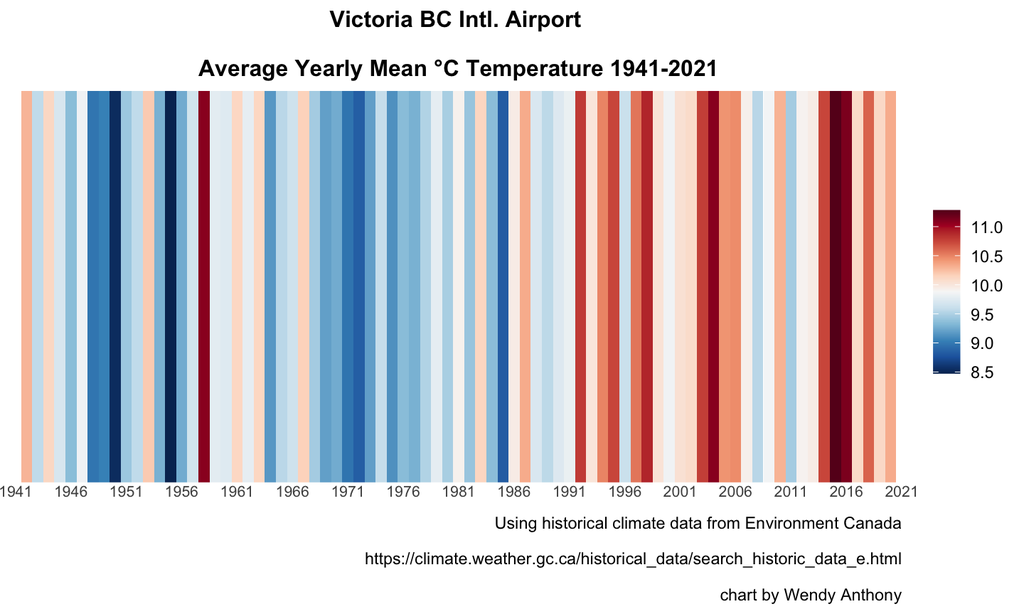

```r
stplt_lg
```

## Create image files with legend

```r
# png files have very poor resolution >>> add res = 300

# pdf files have better resolution
pdf("VictoriaClimateStripes-1941-2021-lg.pdf")
stplt_lg
dev.off()
```

```r
# tiff files have best resolution, with a larger file-size; specify size and resolution
tiff("VictoriaClimateStripes-1941-2021-lg.tiff", units="in", width=5, height=5, res=300)
stplt_lg
dev.off()
```

## Create graphic stripes only, no legend

- geom_tile(show.legend = FALSE)
- use theme_void() to remove all theme styling
- NA values can have a different color by adding na.value = “gray70” to scale_fill_gradientn()

[figure not shown]

```r
stplt <- ggplot(groupby_temp_victoria,
             aes(x = date, y = 1, fill = TempMean)) +
        geom_tile(show.legend = FALSE) +
           scale_x_date(date_breaks = "6 years",
                     date_labels = "%Y",
                     expand = c(0, 0)) +
           scale_y_discrete(expand = c(0, 0)) +
           scale_fill_gradientn(colors = rev(col_strip), na.value = "gray70") +
             theme_void()
stplt
```

## Create image files with no legend

```r
# png files have very poor resolution

# pdf files have better resolution
pdf("VictoriaClimateStripes-1941-2021-nolg.pdf")
stplt
dev.off()
```

```r
# tiff files have best resolution, with a larger file-size; specify size and resolution
tiff("VictoriaClimateStripes-1941-2021-nolg.tiff", units="in", width=5, height=5, res=300)
stplt
dev.off()
```

## Create Temperature Anomaly chart

- For each country-level #ShowYourStripes graphic (Hawkins, June 2019), the average temperature in the 1971-2000 reference period is set (https://en.wikipedia.org/wiki/Warming_stripes)
- Victoria INT’L Airport Climate Normal Data 1971-2000
- Yearly Daily Average Temperature 1971-2000 was 9.7ºC

## add new columns for anomalies

- to groupby_temp_victoria for climate norm, then another for anomaly

```r
groupby_temp_victoria$Norm <- "9.7"
str(groupby_temp_victoria) #chr
```

```
## tibble [81 × 4] (S3: tbl_df/tbl/data.frame)
##  $ Year    : num [1:81] 1941 1942 1943 1944 1945 ...
##  $ TempMean: num [1:81] 10.92 10.29 9.57 10.12 9.69 ...
##  $ date    : Date[1:81], format: "1941-01-01" "1942-01-01" ...
##  $ Norm    : chr [1:81] "9.7" "9.7" "9.7" "9.7" ...
```

```r
# change chr >> num
groupby_temp_victoria$Norm <- as.numeric(groupby_temp_victoria$Norm)

groupby_temp_victoria$Anomaly <- (groupby_temp_victoria$TempMean - groupby_temp_victoria$Norm)
groupby_temp_victoria
```

```
## # A tibble: 81 x 5
##     Year TempMean date        Norm  Anomaly
##    <dbl>    <dbl> <date>     <dbl>    <dbl>
##  1  1941    10.9  1941-01-01   9.7  1.22
##  2  1942    10.3  1942-01-01   9.7  0.587
##  3  1943     9.57 1943-01-01   9.7 -0.132
##  4  1944    10.1  1944-01-01   9.7  0.416
##  5  1945     9.69 1945-01-01   9.7 -0.00932
##  6  1946     9.35 1946-01-01   9.7 -0.348
##  7  1947     9.84 1947-01-01   9.7  0.138
##  8  1948     8.98 1948-01-01   9.7 -0.724
##  9  1949     9.04 1949-01-01   9.7 -0.665
## 10  1950     8.54 1950-01-01   9.7 -1.16
## # … with 71 more rows
```

## create anomaly plot

```r
## stripes plot with the legend

# Define Start and end times for the subset as R objects that are the time class
startTime <- as.Date("1941-01-01")
endTime <- as.Date("2021-01-01")

# create a start and end time R object >>> scale_x_date(limits=start.end,
start.end <- c(startTime,endTime)
start.end
```

```
## [1] "1941-01-01" "2021-01-01"
```

```r
stplt_lg_anom <- ggplot(groupby_temp_victoria,
             aes(x = date, y = 1, fill = Anomaly)) +
        geom_tile() +
           scale_x_date(limits=start.end,
                        date_breaks = "5 years",
                        date_labels = "%Y",
                        expand = c(0, 0)) +
           scale_y_continuous(expand = c(0, 0)) +
           scale_fill_gradientn(colors = rev(col_strip)) +
             guides(fill = guide_colorbar(barwidth = 1)) +
            labs(title = "Victoria BC Intl. Airport
                 \nAnnual °C Temperature Anomaly 1941-2021",
                 subtitle = "(Based on Victoria INT'L Airport Climate Normals 1971-2000)",
                caption = "Using historical climate data from Environment Canada
                \nhttps://climate.weather.gc.ca/historical_data/search_historic_data_e.html
                \n chart by Wendy Anthony") +
          theme_strip
```

## Anomaly Chart

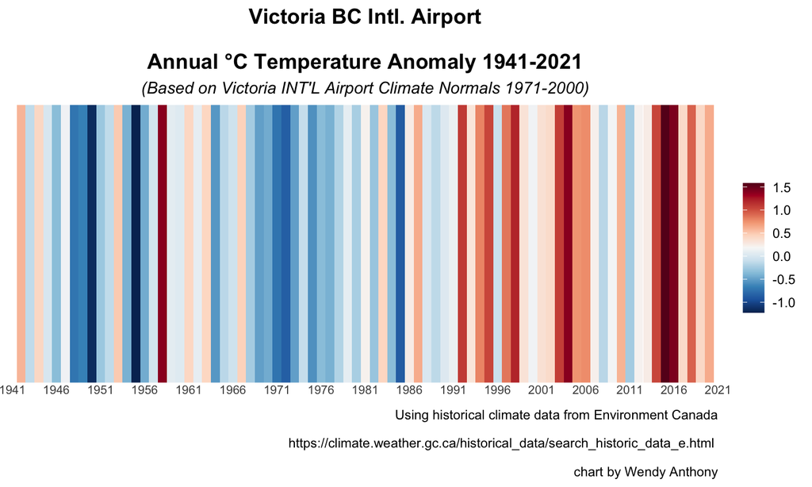

```r
stplt_lg_anom
```

## create plot files of anomaly with legend

```r
# png files have very poor resolution >>> add res = 300

# pdf files have better resolution
pdf("VictoriaClimateStripes-1941-2021-lg-anom.pdf")
stplt_lg_anom
dev.off()
```

```r
# tiff files have best resolution, with a larger file-size; specify size and resolution
tiff("VictoriaClimateStripes-1941-2021-lg-anom.tiff", units="in", width=5, height=5, res=300)
stplt_lg_anom
dev.off()
```

## create anomaly plot with no legend

```r
# Define Start and end times for the subset as R objects that are the time class
startTime <- as.Date("1941-01-01")
endTime <- as.Date("2021-01-01")
# create a start and end time R object >>> scale_x_date(limits=start.end,
start.end <- c(startTime,endTime)
start.end
```

```
## [1] "1941-01-01" "2021-01-01"
```

```r
stplt_nolg_anom <- ggplot(groupby_temp_victoria,
             aes(x = date, y = 1, fill = Anomaly)) +
        geom_tile() +
           scale_x_date(limits=start.end,
                        date_breaks = "5 years",
                        date_labels = "%Y",
                        expand = c(0, 0)) +
           scale_y_continuous(expand = c(0, 0)) +
           scale_fill_gradientn(colors = rev(col_strip)) +
           guides(fill = guide_colorbar(barwidth = 1)) +
           labs(title = "Victoria BC Intl. Airport Mean Temperature°C Anomaly 1941-2021",
                subtitle = "(Based on Env Canada Victoria INT'L Airport Climate Normals 1971-2000)") +
          theme_strip +
          theme(   # modify theme_strip
            legend.position = "none", # no legend
            plot.title=element_text(size = 8), # smaller text size, no line break
            plot.subtitle=element_text(size = 7), # smaller text size
            axis.text.x = element_blank()) # no x-axis text
```

## Display Climate Stripes no legend

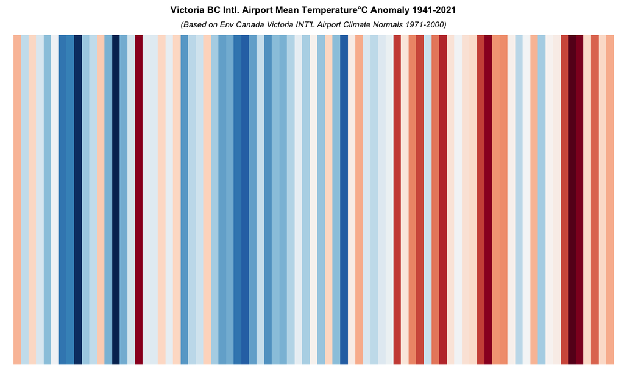

```r
stplt_nolg_anom
```

## create plot files of anomaly without legend

```r
# png files have very poor resolution >>> add res = 300

# pdf files have better resolution
pdf("VictoriaClimateStripes-1941-2021-nolg-anom.pdf")
stplt_nolg_anom
dev.off()
```

```r
# tiff files have best resolution, with a larger file-size; specify size and resolution
tiff("VictoriaClimateStripes-1941-2021-nolg-anom.tiff", units="in", width=5, height=5, res=300)
stplt_nolg_anom
dev.off()
```

## Add text to plot ?????????

- y axis has no value (except 1), so difficult to place; vjust=“top” doesn’t work ???

```r
stplt_txt <- ggplot(groupby_temp_victoria,
             aes(x = date, y = 1, fill = TempMean)) +
        geom_tile(show.legend = FALSE) +
           scale_x_date(date_breaks = "6 years",
                     date_labels = "%Y",
                     expand = c(0, 0)) +
           scale_y_discrete(expand = c(0, 0)) +
           scale_fill_gradientn(colors = rev(col_strip), na.value = "gray70") +
             theme_void() +
  geom_text(x = 1941, y = 1, aes(label = "Victoria INT'L \nMean Temp
                                 \n1941-2021"), vjust = "top", hjust = "center")
#   geom_text(x = 1941, label = "Victoria INT'L Mean Temp 1941-2021") # WORKS
#  annotate(geom = "text", label = "Victoria INT'L Mean Temp 1941-2021", color = "black")
```

## Display add text to plot

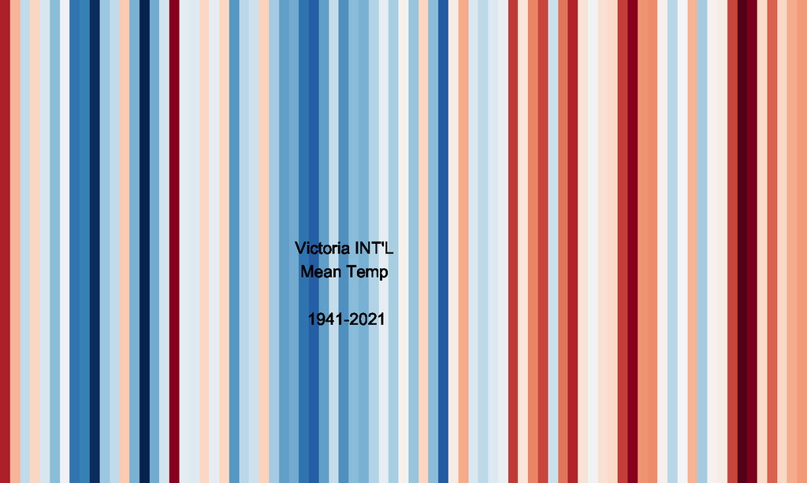

```r
stplt_txt
```

```r
# png files have very poor resolution >>> add res = 300

# pdf files have better resolution
pdf("VictoriaClimateStripes-1941-2021-textplot.pdf")
stplt_txt
dev.off()
```

```r
# tiff files have best resolution, with a larger file-size; specify size and resolution
tiff("VictoriaClimateStripes-1941-2021-textplot.tiff", units="in", width=5, height=5, res=300)
stplt_txt
dev.off()
```

## Add title to plot

```r
stplt_title <- ggplot(groupby_temp_victoria,
             aes(x = date, y = 1, fill = TempMean)) +
        geom_tile(show.legend = FALSE) +
           scale_x_date(date_breaks = "6 years",
                     date_labels = "%Y",
                     expand = c(0, 0)) +
           scale_y_discrete(expand = c(0, 0)) +
           scale_fill_gradientn(colors = rev(col_strip), na.value = "gray70") +
             theme_void() +
  ggtitle("Victoria INT'L Mean Temp 1941-2021") +
theme(plot.title=element_text(hjust=0.37, vjust=0.5, margin=margin(t=60,b=-30)))
```

## Plot with title

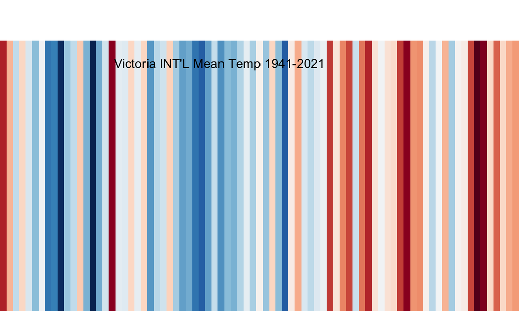

```r
stplt_title
```

```r
# png files have very poor resolution >>> add res = 300

# pdf files have better resolution
pdf("VictoriaClimateStripes-1941-2021-titleplot.pdf")
stplt_title
dev.off()
```

```r
# tiff files have best resolution, with a larger file-size; specify size and resolution
tiff("VictoriaClimateStripes-1941-2021-titleplot.tiff", units="in", width=5, height=5, res=300)
stplt_title
dev.off()
```

## Create Mean Temperature Plot >>> convert verticle bar to round?

```r
## stripes plot with the legend
stplt_lg_rnd <- ggplot(groupby_temp_victoria,
             aes(x = date, y = 1, fill = TempMean)) +
        geom_tile() +
           scale_x_date(limits=start.end,
                        date_breaks = "5 years",
                        date_labels = "%Y",
                        expand = c(0, 0)) +
           scale_y_continuous(expand = c(0, 0)) +
           scale_fill_gradientn(colors = rev(col_strip)) +
             guides(fill = guide_colorbar(barwidth = 1)) +
            labs(title = "Victoria BC Intl. Airport \nAverage Yearly Mean °C Temperature 1941-2021",
                caption = "Using historical climate data from Environment Canada\nhttps://climate.weather.gc.ca/historical_data/search_historic_data_e.html\n chart by Wendy Anthony") +
          theme_strip +
          theme(plot.title=element_text(size = 12)) + # smaller text size, no line break
coord_polar()
```

## Chart with polar coord

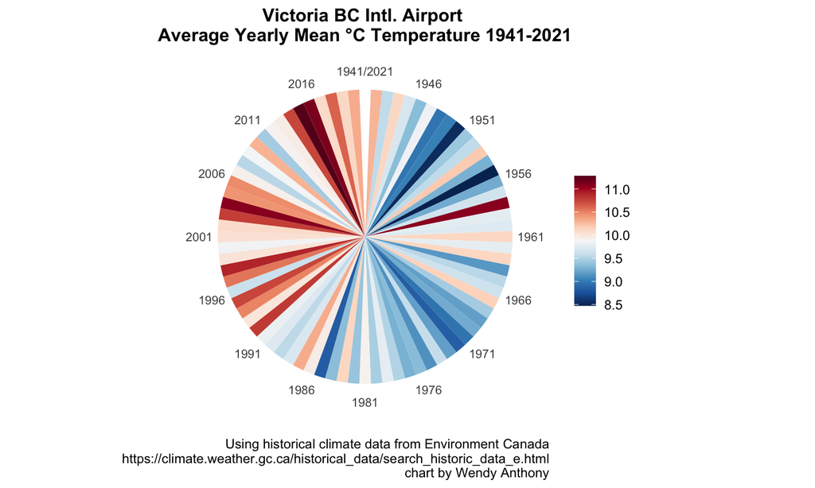

```r
stplt_lg_rnd
```

## create plot files trying for round - coord_polar()

```r
# png files have very poor resolution >>> add res = 300

# pdf files have better resolution
pdf("VictoriaClimateStripes-1941-2021-coordpolar.pdf")
stplt_lg_rnd
dev.off()
```

```r
# tiff files have best resolution, with a larger file-size; specify size and resolution
tiff("VictoriaClimateStripes-1941-2021-coordpolar.tiff", units="in", width=5, height=5, res=300)
stplt_lg_rnd
dev.off()
```

## Create Mean Temperature Plot >>> convert verticle bar to round? ???????

```r
## stripes plot with the legend

stplt_lg_barrnd <- ggplot(groupby_temp_victoria,
             aes(x = date, fill = TempMean)) +
             #scale_y_continuous(expand = c(0, 0)) +
           #scale_fill_gradientn(colors = rev(col_strip)) +
             #guides(fill = guide_colorbar(barwidth = 1)) +
   #theme_strip +
  geom_bar() +
coord_polar(theta = "y")
```

## PLot in round ?

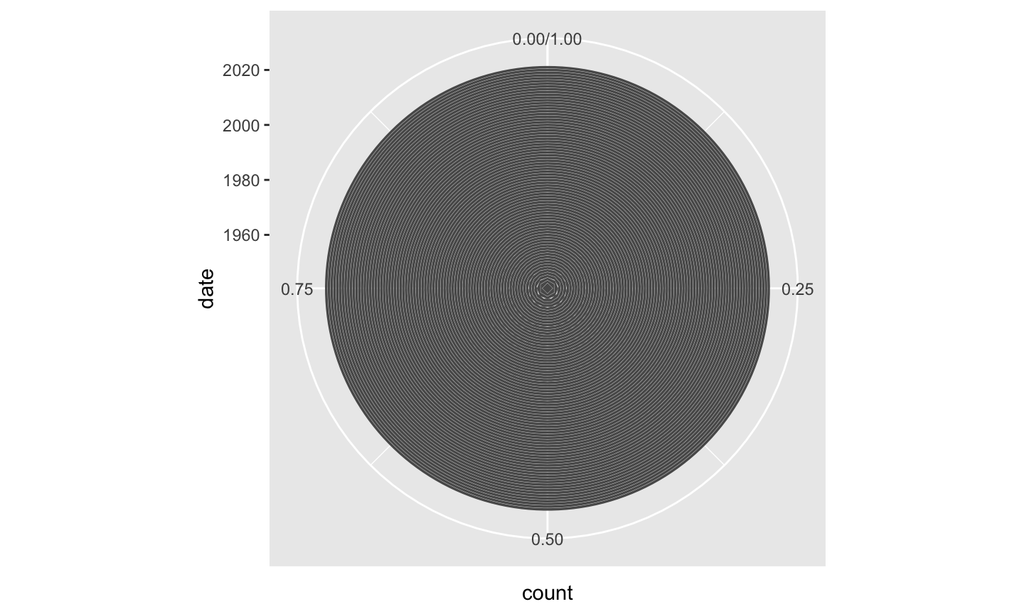

```r
stplt_lg_barrnd
```

## Thanx to:

- Based on 2018 code by Dominic Royé  
  [How to Create Warming Stripes in R](https://www.r-bloggers.com/how-to-create-warming-stripes-in-r/)
- Github for hosting this presentation
- R Markdown ioslides_presentation